# Employee Communications Analytics

# 7 Supporting Categories — Topic and Month

These categories are descriptive only. Categories have small sample sizes and are not adjusted for audience size, post format or message purpose.

```r
topic_summary <- posts |>
  group_by(topic) |>
  summarise(n = n(), median_reach = median(reach_rate),
            median_interaction = median(interaction_rate), .groups = "drop") |>
  arrange(desc(median_interaction))
kable(topic_summary |>
        mutate(median_reach = percent(median_reach, accuracy = 0.1),
               median_interaction = percent(median_interaction, accuracy = 0.1)))
```

| topic | n | median_reach | median_interaction |
| --- | --- | --- | --- |
| Recognition | 5 | 41.8% | 7.3% |
| Culture | 7 | 19.5% | 6.9% |
| Learning | 3 | 23.5% | 6.4% |
| Business Update | 9 | 32.1% | 6.3% |
| Technology | 6 | 18.2% | 5.6% |
| Wellbeing | 2 | 27.5% | 5.5% |
| Community | 2 | 40.3% | 5.4% |
| HR / Benefits | 5 | 33.3% | 4.9% |
| Workplace | 3 | 36.6% | 4.3% |

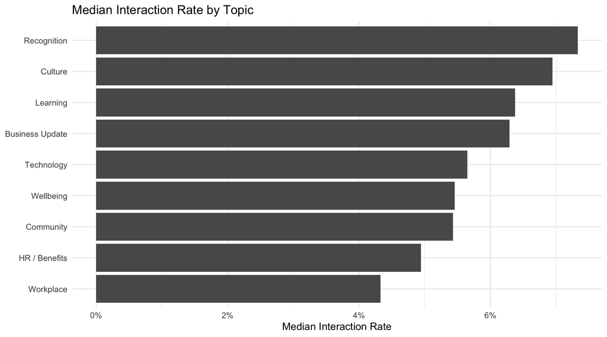

```r
ggplot(topic_summary, aes(reorder(topic, median_interaction), median_interaction)) +
  geom_col() + coord_flip() +
  scale_y_continuous(labels = percent_format()) +
  labs(title = "Median Interaction Rate by Topic",
       x = NULL, y = "Median Interaction Rate") +
  theme_minimal()
```

```r
monthly <- posts |>
  group_by(month_label) |>
  summarise(posts = n(), median_reach = median(reach_rate),
            median_interaction = median(interaction_rate), .groups = "drop")
kable(monthly |> mutate(across(c(median_reach, median_interaction), percent)))
```

| month_label | posts | median_reach | median_interaction |
| --- | --- | --- | --- |
| Sep | 10 | 18.0% | 5.976% |
| Oct | 15 | 33.1% | 7.258% |
| Nov | 17 | 26.2% | 6.074% |

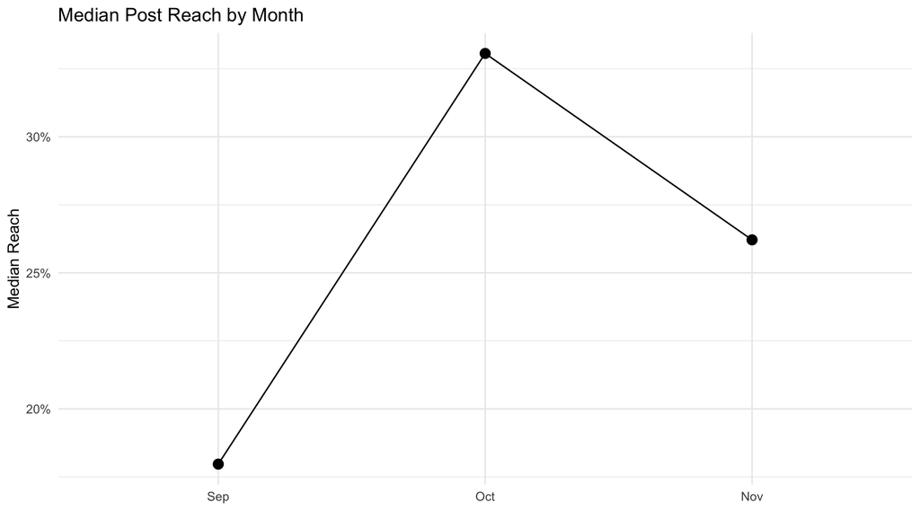

```r
ggplot(monthly, aes(month_label, median_reach, group = 1)) +
  geom_line() + geom_point(size = 3) +
  scale_y_continuous(labels = percent_format()) +
  labs(title = "Median Post Reach by Month", x = NULL, y = "Median Reach") +
  theme_minimal()
```

# 8 Recommendation and Next Steps

**Recommendation:** Adopt a two-lane publishing approach.

- **Use announcements sparingly** For urgent, high-priority or operationally critical information where broad exposure is the primary goal.
- **Use targeted standard posts** For ongoing culture, recognition, learning and community conversations. Comments, reactions and sharing should be the desired outcome.
- For every linked campaign, define the intended action before publishing and report completed action (for example, completed survey, enrollment, training completion), not clicks alone.

This recommendation comes from the following observation: announcements were associated with substantially higher reach, while standard posts had higher interaction per viewer. It does not assume that one format is universally better.

## 8.1 What to Investigate Before Making Firm Conclusions

1. **Audience composition and targeting:** Which communities and employee groups were eligible to see each post? Were the audience sizes accurate and comparable?
2. **Purpose and urgency:** Were announcements used for more important or mandatory messages? Compare like-for-like topics and objectives.
3. **Timing and exposure:** Posting time, time zone, competing messages, and duration of exposure may affect performance; the export only provides date/day.
4. **Content quality:** Test headline, length, visual, call-to-action clarity and sender effects with controlled or matched comparisons.